# REsurety Power Market Assessment

## Estimate The Clearing Price

The Electric Reliability Council of Texas (ERCOT) manages the power market for Texas. In each hour, ERCOT dispatches generation in order to meet market demand in a manner that minimizes the costs to customers.

The core of this process involves estimating the system-wide supply curve, which describes the relationship between market price and market generation.

To make this estimate, ERCOT gathers price/quantity bids from every generator in its territory for every hour of the day. The generators report the price at which they would be willing to sell various levels of generation (see example below).

ERCOT aggregates this Security Constrained Economic Dispatch (SCED) data into a system-wide supply curve, describing how much energy is available to the whole market at various prices.

In addition to an hourly supply curve, ERCOT also estimates hourly demand.

The “clearing price” in a given hour is the price of power at which the supply curve crosses the demand curve.

### Your Objective

Your task for this assessment assignment is to **estimate the clearing price for each hour** based on the SCED data and the demand data from ERCOT.

### The Data

We have given you a CSV file of SCED data from ERCOT. The file shows the quantity and price bids for every generator in Texas at 1-hour intervals for a full day (`SCED_Data.csv`).

You also have the system demand for each of the 24 time stamps (`DemandData.csv`).

With supply of electricity (the offer curves) and clearing demand of electricity, your task is to estimate the clearing price for each 1-hour time interval in the data.

We have also included a CSV with column names and descriptions, for your convenience.

### Additional Notes

A lot goes into the actual clearing price beyond just the system-wide supply curve. Don’t try to model everything, and don’t pull in additional data beyond what has been given. We’re looking at thought process and domain knowledge.

Please use any assumptions you feel are necessary, and tell us what they are. Note that the maximum capacity for ERCOT on this particular day was 15.6 GW.

You may use any tools you need to complete this exercise. That said, we work in code at REsurety; we would like to get a sense for your coding skills in this exercise; as such we would prefer you not do your analysis in Excel.

### Some R code to get you started…

For the purposes of this exercise, the most important component of finding the clearing price is the supply curve. The `SCED_Data.csv` file contains enough information to estimate system-wide supply.

The following example is in R, because that’s what we use most at REsurety. You are not required to use R to complete the assignment.

Step one is to read in the data and examine it.

```r
# Load the data (we use the data.table package, but that is not required)
sced <- data.table::fread("SCED_Data.csv")

# Make sure R recognizes this as a Time stamp
sced[, Time := as.POSIXct(Time, format = "%Y-%m-%d %H:%M:%S", tz = "US/CENTRAL")]

# For example purposes, let's look at the data for one generator at one time stamp
sced <- sced[Time == min(Time) & Resource.Name == "BASTEN_CC1_2"]

# Limit the columns shown for demonstration purposes
sced[, 1:24]
```

```
##          Time Resource.Name Resource.Type SCED1.Curve.MW1
## 1: 2016-05-05  BASTEN_CC1_2        CCGT90               0
##    SCED1.Curve.Price1 SCED1.Curve.MW2 SCED1.Curve.Price2 SCED1.Curve.MW3
## 1:               -250             265               -250             265
##    SCED1.Curve.Price3 SCED1.Curve.MW4 SCED1.Curve.Price4 SCED1.Curve.MW5
## 1:              11.89             313              12.34             351
##    SCED1.Curve.Price5 SCED1.Curve.MW6 SCED1.Curve.Price6 SCED1.Curve.MW7
## 1:               13.2             390              14.06             428
##    SCED1.Curve.Price7 SCED1.Curve.MW8 SCED1.Curve.Price8 SCED1.Curve.MW9
## 1:              14.92             532              16.49             532
##    SCED1.Curve.Price9 SCED1.Curve.MW10 SCED1.Curve.Price10
## 1:               61.4              554                61.4
##    SCED1.Curve.MW11
## 1:              554
```

In the above data, you can see that this generator is willing to sell 313 MW for a price of $12.34 (`SCED1.Curve.MW4` and `SCED1.Curve.Price4`, respectively), 351 MW for $13.2, etc.

To see this more clearly, here’s a plot of this generator’s supply curve in the first hour of the day (omitting the final bid at $9000/MW).

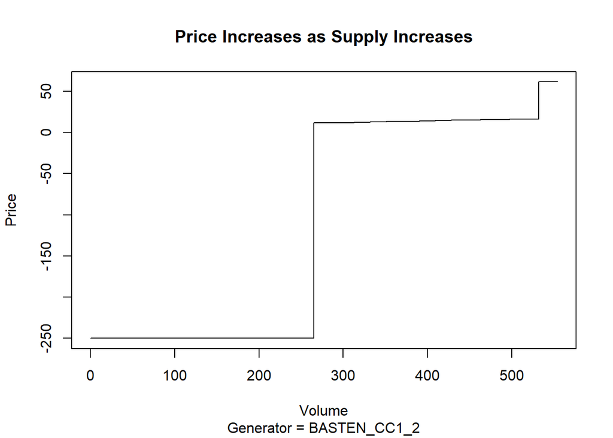

### Please Deliver the Following to the Hiring Manager:

- Your main deliverable is a time series showing 24 market clearing prices, one for each hour in the data set. (Visualization optional).
- Please also answer the following questions:
  - What other data would you need to give a more precise estimate of the clearing price?
  - How can we improve the clarity or realism of this exercise?
- Please also provide:
  - The code you used to produce your results
  - Your name and contact information

### Expectations

- This isn’t meant to be an in-depth consulting project or second job. We’re expecting this to take 2-3 hours at the most.
- Results should reflect your work only.